# Optimization in Finance

## Maximum Entropy Distribution of an Asset Inferrred from Option Prices

Bertrand Le Nezet / 30-Mar-2015

## Numerical implementation steps

1. Option prices snap from Google Finance API
2. Data cleaning:
   - Calculate mid from bid / ask
   - Keep only relevant option prices (put-call parity/liquidity)
3. Apply the Cross Entropy Minimization algorithm
4. Compute option prices from asset distribution
5. Convert option prices into Black-Scholes Implied Volatility

## GOOG.OQ Option quotes

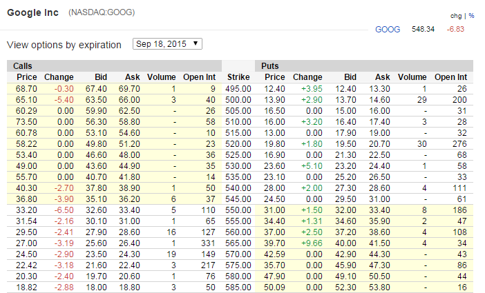

## Put-Call parity

\(d_{1}=\frac{1}{\sigma\sqrt{T-t}}\left[ln\left(\frac{S}{K}\right)+(r-\frac{\sigma^{2}}{2})(T-t)\right]\)

\(d_{2}=\frac{1}{\sigma\sqrt{T-t}}\left[ln\left(\frac{S}{K}\right)+(r-\frac{\sigma^{2}}{2})(T-t)\right]\)

Call option: \(C(S,t)=N(d_{1})S-N(d_{2})Ke^{-r(T-t)}\)

Put Option: \(P(S,t)=-N(-d_{1})S+N(-d_{2})Ke^{-r(T-t)}\)

Put-Call parity: \(C(t)+Ke^{-r(T-t)}=P(t)+S(t)\)

## Volatility smile

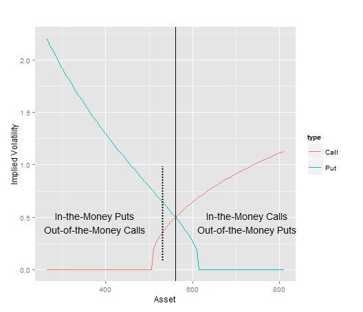

## Cross Entropy Minimization algorithm

Minimize \(S(p,q)=\int_{-\infty}^{\infty}p(x)\log\left[\frac{p(x)}{q(x)}\right]dx\)

Subject to:

- \(\int_{0}^{\infty}p(x)dx=1\)
- \(\forall i=1,2,..m\;\mathbb{E}\left[c_{i}(X)\right]=\int_{0}^{\infty}p(x)\; c_{i}(x)dx=ci\)
1. A uniform distribution is used as a prior (non-informed prior)
2. Integrability constraint
3. Option prices used as constraints should be linearly independant
4. Forward is also used as a constraint (mean)
5. Choice of asset step for the discretisation / boundaries
6. Lagrangian function is minimized using an optimization routine (Limited-memory Broyden-Fletcher-Goldfarb-Shanno)

## GOOG.OQ Asset distribution

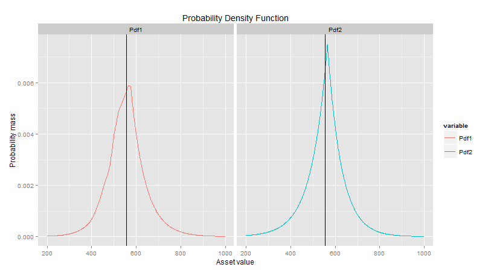

Pdf1: Asset distribution inferred from 9 option prices

Pdf2: Asset distribution inferred from 1 option price

## Asset distribution with constant volatility (25%)

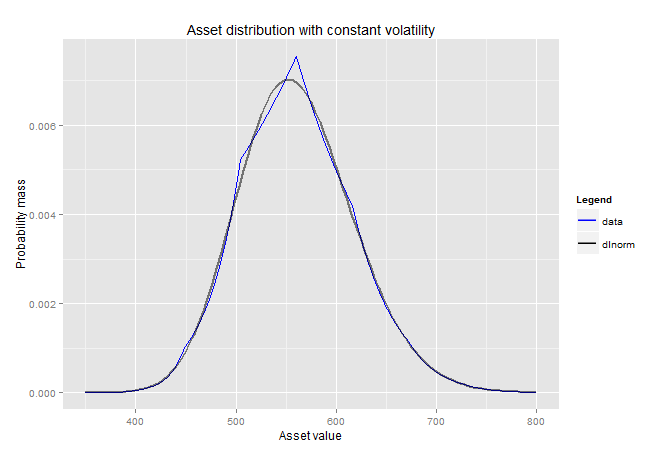

Asset distribution inferred from 6 option prices (constant volatility)

## GOOG.OQ Volatility smile

\(c(K)=D(T)\int_{0}^{\infty}p(x)\;\left(x-K\right)^{+}dx\)

\(p(K)=D(T)\int_{0}^{\infty}p(x)\;\left(K-x\right)^{+}dx\)

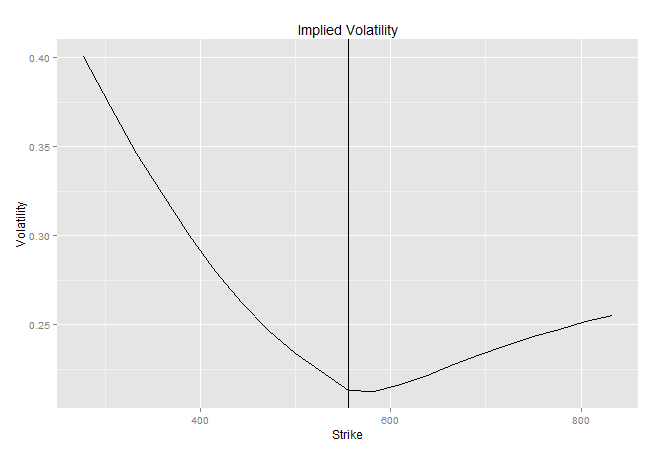

## Conclusion

1. We have observed that assets distribution inferred from options prices are not log-normal (i.e. Volatility is not constant)
2. Principle of Minimum Cross-Entropy can be used to estimate the distribution of an asset without assuming a particular distribution shape or family of distribution (non-parametric approach)
3. The algorithm is stable and fast
4. This method can be used to perform implied volatility interpolation/extrapolation from only few quotes

## Thank You

## References

- [BuchenKelly96] The Maximum Entropy Distribution of an Asset Inferred from Option Prices (Peter W. Buchen, Michael Kelly)

## Appendix

## Kullback-Leibler Relative entropy

1. In Information Theory, Shannon defines the entropy as a measure of unpredictability of information content
2. the KL relative entropy (or KL divergence) is a non-suymetric mesure of the difference between two probability distribution P and Q.
3. \(D_{KL}(P\Vert Q)=\int_{-\infty}^{\infty}p(x)\ln\frac{p(x)}{q(x)}dx\)
4. Properties:
5. KL is equal to zero if P and Q are identical
6. KL relative entropy is always positive

## Calculation of Relative Entropy

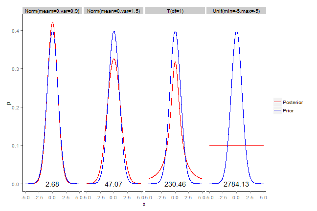

## Formulating the Optimization problem

We have one prior probability density function \(q(x)\)

We have \(m\) price constraints: \(\forall i=1,2,..m\; d_{i}=D(T)\mathbb{E}_{\mathbb{Q}}\left[c_{i}(X_{T})\right]\) where

- \(D(T)=e^{-(r-q)T}\) represents the discount factor
- \(c_{i}(X_{t})\) denotes the $i$th option pay-off function at expiry depenent only on the asset value at expiry
- $d_{i}$is the corresponding option price
- \(r\) risk-free rate for \(T\)
- \(q\) dividend yield

## Formulating the Optimization problem (2)

Minimize \(S(p,q)=\int_{-\infty}^{\infty}p(x)\log\left[\frac{p(x)}{q(x)}\right]dx\)

Subject to 2 constraints:

1. \(\int_{0}^{\infty}p(x)dx=1\)
2. \(\forall i=1,2,..m\;\mathbb{E}\left[c_{i}(X)\right]=\int_{0}^{\infty}p(x)\; c_{i}(x)dx=ci\)

This is a standard constrained optimization problem which solved by using the method of Lagrange which transforms a problem in n variable and m constraints into an unconstrainted optimization with n+m variables.

## Objective function

\(H(p)=-\int_{0}^{\infty}p(x)\log\left[\frac{p(x)}{q(x)}\right]dx+(1+\lambda_{0})\int_{0}^{\infty}p(x)dx+\sum_{i=1}^{m}\lambda_{i}\int_{0}^{\infty}p(x)\; c_{i}(x)dx\)

From standard calculus, we know that the minimum \(\lambda^{*}=(\lambda_{0}^{*},\ldots,\lambda_{M}^{*})\) is reached when:

- the gradient (vector of derivatives)\(\delta H\) is equal to zero: \(\delta H(\lambda^{*})=\int_{0}^{\infty}\left[-\log\left[\frac{p(x)}{q(x)}\right]+\lambda_{0}+\sum_{i=1}^{m}\lambda_{i}c_{i}(x)\right]\delta p(x)dx=0\) (necessary condition)
- the hessian (matrix of second derivatives) is positive definite (sufficient condition)

## Objective function solution

This leads immediately to the following explicit representation of the MED:

\(p(x)=\frac{q(x)}{\mu}\exp\left(\sum_{i=1}^{m}\lambda_{i}c_{i}(x)\right)\), \(\mu=\int_{0}^{\infty}q(x)\exp\left(\sum_{i=1}^{m}\lambda_{i}c_{i}(x)\right)dx\)

## Impact of constraints on MXED

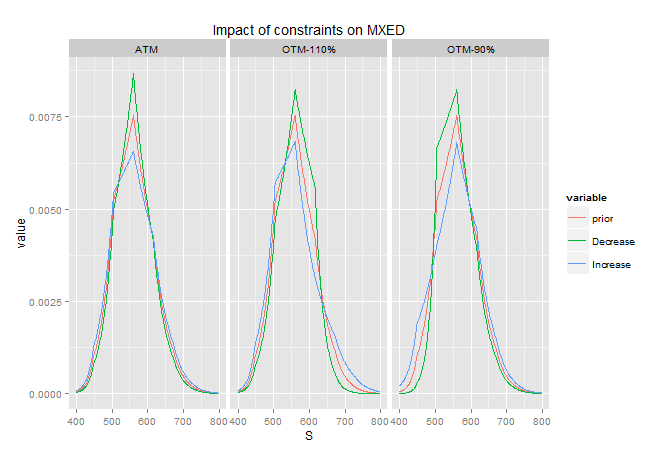